# Bone Data Cleaning

Goutham Swaminathan

2018-10-10

I will brief*ly explain my process for reading shape data from a MATLAB data file, converting it into a usable data frame in R, and plotting the results.

## Setup

I will use libraries **R.matlab** and **tidyverse** for this process. **R.matlab** is used to read the MATLAB data file and **tidyverse** will be used to visualize the data, specifically the package **ggplot2**.

```r
library(R.matlab)
library(tidyverse)

knitr::opts_chunk$set(echo = TRUE,
  warning = FALSE,
  message = FALSE,
  fig.width = 9,
  fig.height = 4
)

theme_set(theme_bw() + theme(legend.position = "none"))
```

## Read data

```r
similarShapes = readMat('../data/SimilarSample.mat')
```

Since the data is organized into 3 sections, each with 7 bones made up of 100 x- and y- coordinates, we will need to modify the format slightly to create an R data frame.

## Clean data

We will create **x** and **y** variables to store the respective values.

```r
x = similarShapes$A1[1, , 1]
y = similarShapes$A1[2, , 1]
```

We will then use *data.frame()* to bind the vectors, categorize the values by bone id, and assign the result to **bone_list**. Afterwards, we can add the other bones by creating separate data frames for each bones and using *rbind()* to bind the result to **bone_list**.

```r
bone_list = data.frame("id" = factor(1), "x" = x, "y" = y)

for(i in 2:7){
  x = similarShapes$A1[1, , i]
  y = similarShapes$A1[2, , i]

  bones = data.frame("id" = factor(i), "x" = x, "y" = y)

  bone_list = rbind(bone_list, bones)
}
```

## Visualize data

We will then visualize the data by using the *ggplot()* and *geom_path()* functions as well as *facet_wrap()* to group the separate plots into 1 large figure and *theme()* to position the legend at the bottom.

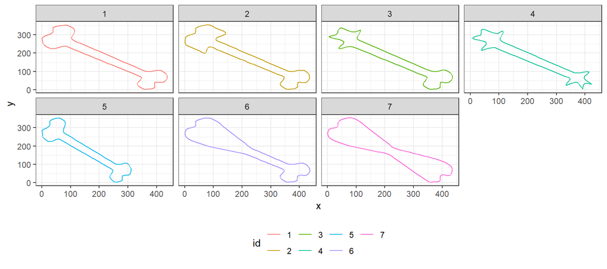

```r
id = bone_list$id

ggplot(bone_list, aes(x, y, color = id)) +
  geom_path() +
  facet_wrap(~ id, ncol = 4) +
  theme(legend.position = "bottom")
```

## Save data

Finally, we will use the *save()* function to save our **.RData** file to a specified directory.

```r
save(bone_list, file = "../rdata/bone_list.RData")
```

## Conclusion

Thank you for taking the time to read this markdown for “Bone Data Cleaning”. Please feel free to visit my GitHub page at http://github.com/goutham1220 for more information.